# CowenProject

Project Name: Models for forecasting companies' market cap and S&P Rating

File editor: Yifan Li

Lastly edited on Feb.1st 2020

This is the ipynb file for the Cowen Project about building,training and judging model for making prediction on Mkt_Cap and S&P Rating. The Reason why I use ipynb file is it combines the code with my text explaination closely, which helps readers easily follow my logics and steps. In every step, I will make detailed explaination on what I am doing,why I am doing this and the URL of online reference(if needed).

1 . reading and processing data

we firstly import some basic packages and read the dataset from the txt file and set some parameters

```python
import pandas as pd
import numpy as np
import math
import missingno as msno

df = pd.read_csv("Raw Data Set.txt",delimiter='\t')
pd.set_option('display.max_rows', None)
pd.set_option('display.max_columns', None)
```

currently, all data are in String format. Besides the String variable like 'S&P Rating' and 'industry', we need to transfer the numerical variables to float format, so I develop a function named "toNum" to transfer the numerical variables.

```python
StringParaNameList=['Ticker', 'Name', 'S&P Rating', 'country', 'industry']

def toNum(x):
    try:
        return float(x)
    except ValueError:
        return np.nan
for (columnName, columnData) in df.iteritems():
    if columnName not in StringParaNameList:
        newData=[toNum(x) for x in columnData.values]
        df[columnName]=newData
```

It is time to clean the data. firstly, since "Mkt cap" is response variable, the sample without "Mkt cap" data is meaningless, so we drop this kind of samples. Then, some samples lack too many variable data, so I set a threshold as 20 and delete the samples with less than 20 available variables in the dataset.

```python
#the following 2 lines of codes as comments are used to see the total types of Rating, it is ununnecessary to be executed in this file
#dups = df.pivot_table(index=['S&P Rating'], aggfunc='size')
#print (dups)

df.dropna(subset=['Mkt cap'],inplace=True)
df.dropna(thresh=20,inplace=True)
```

For feature selection and model comparison, I want to transfer the S&P Rating into numerical variable, after I get the excel file of S&P Rating, I develop a easy an reasonable methods to do this: we firstly count the number of occurrences of each type of Rating and convert it into percentage, then, from 0 to 1, we allocate the [0,1] space to every rating from low to high and the allocation size is depending on the percentage. For example, the percentage of lowest rating "CC" is 2%, then [0,2%] is for "CC", the next higher rating is "CCC-" with percentage 5%, then [2%,7%] is for "CCC-"... then we use the middle point of each space as the numerical value of the corresponding Rating.(I did these in the "Rating.elsx")

```python
#the following 2 lines of codes as comments are used for getting the data in excel for proccessing the data.
#it is ununnecessary to be executed in this file
#df_Rating=df['S&P Rating']
#df_Rating.to_csv("Rating.csv",index=False)

df_RatingTransResult = pd.read_excel("RatingTransferResult.xlsx")
df['N S&P Rating']=df_RatingTransResult.values
```

Notice that there are more than 300 categories of industries in the dataset.We really need to simply the industries, we use Global Industry Classification Standard to process the data in excel

Reference URL:https://en.wikipedia.org/wiki/Global_Industry_Classification_Standard

```python
#the following 4 lines of codes as comments are used for getting the data in excel for proccessing the data.
#it is ununnecessary to be executed in this file
#df_Industry=df['industry']
#df_Industry.to_csv("Industry.csv",index=False)
#df_CategoryIndustry=pd.DataFrame(list(set(df['industry'])))
#df_CategoryIndustry.to_csv("IndustryCategory.csv",index=False)

df_NewIndustry = pd.read_excel("NewIndustryCategory.xlsx")

df['industry']=df_NewIndustry.values
```

Let's see what the dataset looks like, it is showed below, the white line in the picture means "NaN"

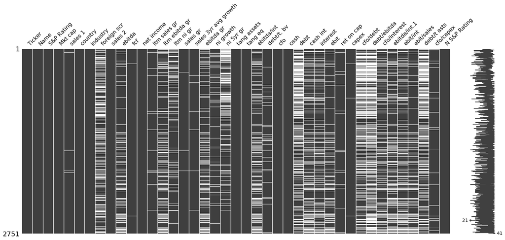

```python
msno.matrix(df).figure
```

I generate a idea to fill in these missing point: generally speaking, among all financial variables, the ratio-like variables are mostly industry-relevant, meaning we can group the dataset by different industries and use the average value of each group to fill in the missing values in this group.And since some variables have few missing points, we can also use this method to fill in the missing point for this kind of variables.

```python
#name of industry related variables
IndustryRelated=['sales 1','fcf','ltm sales gr','sales gr','sales 3yr avg growth','ret on cap','capex','ebitda/int','debt/t. bv','cfo/debt',
                'debt/ebitda','cfo/interest','ebitda/int.1','ebit/int','ebit/sales','debt/t asts','cfo/capex']
IndustryList=list(set(df['industry'].values))

group_df=df.groupby('industry')
for IndustryName in IndustryList:
    temp_df=group_df.get_group(IndustryName)
    for FactorName in IndustryRelated:
        temp_df[FactorName].fillna(temp_df[FactorName].median(),inplace=True)
    df.update(temp_df)
```

Then we deal with the remaining missing points, the variable "foreign scr" miss many values, as a reasonable assumption, we think it is like a deposit or insurance money in the foreign countries, so the reason for the missing points is many companies do not have a multinational business. So in this column, we will in the blank with 0. In the ramaining variables like "cash", "debt" and "growth rate", besides the industry, they are also relevant to the company size, such as big company always has more money and lower growth rate. So according to the online reference, we divide the sample into "L","M","S" groups, and use two dimensions-industry and company size to group the sample and use the average value of each group to fill in the missing point.

Reference URL:https://financialengines.com/education-center/small-large-mid-caps-market-capitalization/

```python
df['foreign scr'].fillna(0,inplace=True)
msno.matrix(df).figure

#process and get the corresponding company size in excel
#df['Mkt cap'].to_csv("Mkt cap.csv")
df['Mkt cap rank']=pd.read_excel("Mkt Cap Ranking.xlsx").values

IndustryNCapRelated=['ebitda','ltm ebitda gr','ltm ni gr','ebitda gr','ni growth','ni 5yr gr','debt','cash int','interest','ebit']
for IndustryName in IndustryList:
    for rank in ['L','M','S']:
        temp=df[df['industry']==IndustryName].groupby('Mkt cap rank').get_group(rank)
        for factorName in IndustryNCapRelated:
            temp[factorName].fillna(temp[factorName].median(),inplace=True)
        df.update(temp)
```

Finally, we drop the samples with missing points, devide the whole dataset into response variables and independent variables.

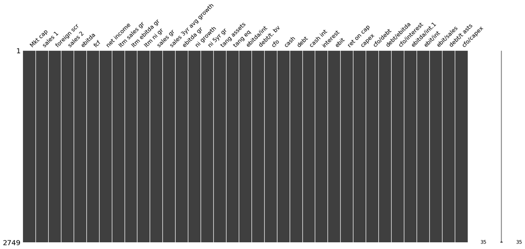

```python
df.dropna(inplace=True)
Y_Rating=df['S&P Rating']
#capital N means numerical
Y_N_Rating=df['N S&P Rating']
df.drop(['S&P Rating','Ticker','Name','Mkt cap rank','country','industry','N S&P Rating'],axis=1,inplace=True)
msno.matrix(df).figure
```

This step is to drop some samples with outliers which could have great influence on the PCA and model fitting

```python
from scipy import stats
temp_boolean=(np.abs(stats.zscore(df)) < 3).all(axis=1)
df=df[temp_boolean]
Y_Rating=Y_Rating[temp_boolean]
Y_N_Rating=Y_N_Rating[temp_boolean]
```

2 . feature selection with Spearman Correlation PCA and RFE

Since normal standardization method will sabotage the variance of variabled, according to the reference, we use RobustScaler to process the data for PCA and RFE

Reference URL:https://scikit-learn.org/stable/auto_examples/preprocessing/plot_all_scaling.html

```python
from sklearn.preprocessing import RobustScaler
transformer = RobustScaler().fit(df)
scaled_df_for_PCA=pd.DataFrame(transformer.transform(df),columns=df.columns)

scaled_Y_MktCap=scaled_df_for_PCA['Mkt cap']
scaled_Y_Rating=Y_Rating
scaled_Y_N_Rating=Y_N_Rating
scaled_df_for_PCA.drop(['Mkt cap'],axis=1,inplace=True)
```

We use Spearman correlation because Pearson correlation requires variables follow multivariant normal distribution and Spearman correlation will not be influenced by extreme values.

```python
scaled_df_for_PCA.corr(method='spearman')
```

|  | sales 1 | foreign scr | sales 2 | ebitda | fcf | net income | ltm sales gr | ltm ebitda gr | ltm ni gr | sales gr | sales 3yr avg growth | ebitda gr | ni growth | ni 5yr gr | tang assets | tang eq | ebitda/int | debt/t. bv | cfo | cash | debt | cash int | interest | ebit | ret on cap | capex | cfo/debt | debt/ebitda | cfo/interest | … |
| --- | --- | --- | --- | --- | --- | --- | --- | --- | --- | --- | --- | --- | --- | --- | --- | --- | --- | --- | --- | --- | --- | --- | --- | --- | --- | --- | --- | --- | --- | --- |
| sales 1 | 1.000000 | 0.187535 | 0.996535 | 0.866729 | 0.483860 | 0.749592 | 0.006075 | 0.099402 | 0.029024 | 0.030192 | 0.021743 | 0.094536 | 0.070630 | 0.066988 | 0.812394 | 0.483449 | 0.303813 | 0.084481 | 0.691248 | 0.805637 | 0.735250 | 0.389600 | 0.763445 | 0.828703 | 0.154048 | -0.724707 | 0.138629 | -0.188993 | 0.299123 | … |
| foreign scr | 0.187535 | 1.000000 | 0.188238 | 0.124846 | 0.147675 | 0.078032 | 0.041163 | 0.020939 | 0.000066 | 0.018082 | -0.056333 | 0.019309 | 0.032027 | -0.031223 | 0.049797 | -0.019444 | 0.175742 | -0.064147 | 0.135453 | 0.165631 | 0.099905 | 0.158705 | 0.092436 | 0.109340 | 0.032547 | -0.127870 | 0.074830 | -0.087756 | 0.100138 | … |
| sales 2 | 0.996535 | 0.188238 | 1.000000 | 0.869490 | 0.486359 | 0.752080 | -0.008906 | 0.094648 | 0.025036 | 0.022271 | 0.020209 | 0.090037 | 0.067413 | 0.066682 | 0.817147 | 0.485256 | 0.303238 | 0.086606 | 0.693403 | 0.808809 | 0.737326 | 0.390160 | 0.764272 | 0.831694 | 0.150668 | -0.724646 | 0.137194 | -0.188225 | 0.301865 | … |
| ebitda | 0.866729 | 0.124846 | 0.869490 | 1.000000 | 0.493700 | 0.853653 | 0.024217 | 0.135499 | 0.045536 | 0.062788 | 0.067642 | 0.146077 | 0.099906 | 0.146075 | 0.854866 | 0.540296 | 0.342279 | 0.120806 | 0.750217 | 0.782954 | 0.779763 | 0.424436 | 0.810299 | 0.959729 | 0.217996 | -0.748518 | 0.135386 | -0.156084 | 0.330961 | … |
| fcf | 0.483860 | 0.147675 | 0.486359 | 0.493700 | 1.000000 | 0.482043 | -0.036056 | 0.027244 | 0.011506 | -0.020098 | 0.017384 | 0.048670 | 0.072874 | 0.067383 | 0.399511 | 0.151386 | 0.342581 | -0.099718 | 0.762752 | 0.455928 | 0.389651 | 0.502904 | 0.366314 | 0.497537 | 0.216557 | -0.239764 | 0.356566 | -0.216143 | 0.478189 | … |
| net income | 0.749592 | 0.078032 | 0.752080 | 0.853653 | 0.482043 | 1.000000 | 0.033455 | 0.130960 | 0.092332 | 0.067085 | 0.098351 | 0.150007 | 0.116083 | 0.220753 | 0.750656 | 0.532363 | 0.406746 | 0.115822 | 0.664268 | 0.692388 | 0.679555 | 0.464581 | 0.626733 | 0.888847 | 0.345123 | -0.606506 | 0.140095 | -0.193582 | 0.405803 | … |
| ltm sales gr | 0.006075 | 0.041163 | -0.008906 | 0.024217 | -0.036056 | 0.033455 | 1.000000 | 0.433237 | 0.222235 | 0.859129 | 0.354488 | 0.411072 | 0.297262 | 0.172517 | -0.044397 | 0.024503 | 0.050781 | 0.001545 | -0.006147 | -0.025100 | 0.020541 | 0.016670 | 0.003612 | 0.024136 | 0.142119 | -0.053010 | -0.018243 | 0.035358 | 0.008330 | … |
| ltm ebitda gr | 0.099402 | 0.020939 | 0.094648 | 0.135499 | 0.027244 | 0.130960 | 0.433237 | 1.000000 | 0.340930 | 0.406213 | 0.146662 | 0.771649 | 0.313347 | 0.095306 | 0.134994 | 0.140549 | 0.036550 | 0.062040 | 0.035958 | 0.149424 | 0.125892 | 0.057276 | 0.074648 | 0.154889 | 0.134124 | -0.054260 | -0.033260 | -0.031278 | 0.062759 | … |
| ltm ni gr | 0.029024 | 0.000066 | 0.025036 | 0.045536 | 0.011506 | 0.092332 | 0.222235 | 0.340930 | 1.000000 | 0.215097 | 0.079692 | 0.315034 | 0.358103 | 0.087235 | -0.001313 | 0.008412 | 0.000342 | -0.011748 | 0.031314 | -0.009599 | 0.039608 | -0.004902 | 0.045258 | 0.031225 | 0.179346 | -0.064696 | -0.028270 | 0.034346 | -0.019586 | … |
| sales gr | 0.030192 | 0.018082 | 0.022271 | 0.062788 | -0.020098 | 0.067085 | 0.859129 | 0.406213 | 0.215097 | 1.000000 | 0.435185 | 0.456576 | 0.318729 | 0.185931 | -0.013149 | 0.049115 | 0.061255 | 0.021817 | 0.022213 | -0.000430 | 0.055416 | 0.039387 | 0.036165 | 0.058906 | 0.153930 | -0.074394 | -0.012208 | 0.023908 | 0.029688 | … |
| sales 3yr avg growth | 0.021743 | -0.056333 | 0.020209 | 0.067642 | 0.017384 | 0.098351 | 0.354488 | 0.146662 | 0.079692 | 0.435185 | 1.000000 | 0.172707 | 0.132984 | 0.380553 | -0.002627 | -0.037770 | 0.001457 | -0.026316 | 0.011068 | 0.034542 | 0.069438 | 0.007634 | 0.023990 | 0.092806 | 0.155206 | 0.003759 | -0.000661 | 0.038089 | 0.007481 | … |
| ebitda gr | 0.094536 | 0.019309 | 0.090037 | 0.146077 | 0.048670 | 0.150007 | 0.411072 | 0.771649 | 0.315034 | 0.456576 | 0.172707 | 1.000000 | 0.396093 | 0.102246 | 0.110774 | 0.123529 | 0.077033 | 0.045238 | 0.056017 | 0.133503 | 0.105490 | 0.071340 | 0.077652 | 0.166388 | 0.138163 | -0.053985 | -0.010269 | -0.064253 | 0.074941 | … |
| ni growth | 0.070630 | 0.032027 | 0.067413 | 0.099906 | 0.072874 | 0.116083 | 0.297262 | 0.313347 | 0.358103 | 0.318729 | 0.132984 | 0.396093 | 1.000000 | 0.233228 | 0.059803 | 0.060424 | 0.074224 | 0.018981 | 0.075422 | 0.081180 | 0.078006 | 0.086506 | 0.067476 | 0.098186 | 0.124405 | -0.061810 | 0.000731 | 0.009562 | 0.065622 | … |
| ni 5yr gr | 0.066988 | -0.031223 | 0.066682 | 0.146075 | 0.067383 | 0.220753 | 0.172517 | 0.095306 | 0.087235 | 0.185931 | 0.380553 | 0.102246 | 0.233228 | 1.000000 | 0.108242 | 0.084349 | 0.116361 | 0.044318 | 0.098275 | 0.067322 | 0.122498 | 0.120359 | 0.057792 | 0.179659 | 0.206183 | -0.072468 | -0.051545 | 0.039529 | 0.119293 | … |
| tang assets | 0.812394 | 0.049797 | 0.817147 | 0.854866 | 0.399511 | 0.750656 | -0.044397 | 0.134994 | -0.001313 | -0.013149 | -0.002627 | 0.110774 | 0.059803 | 0.108242 | 1.000000 | 0.732887 | 0.139716 | 0.287209 | 0.652985 | 0.827329 | 0.741422 | 0.295477 | 0.752135 | 0.824621 | -0.039031 | -0.672558 | 0.046578 | -0.118765 | 0.286744 | … |
| tang eq | 0.483449 | -0.019444 | 0.485256 | 0.540296 | 0.151386 | 0.532363 | 0.024503 | 0.140549 | 0.008412 | 0.049115 | -0.037770 | 0.123529 | 0.060424 | 0.084349 | 0.732887 | 1.000000 | 0.099208 | 0.487257 | 0.373674 | 0.554513 | 0.447337 | 0.246441 | 0.409683 | 0.532654 | -0.120758 | -0.462457 | 0.045743 | -0.098394 | 0.266503 | … |
| ebitda/int | 0.303813 | 0.175742 | 0.303238 | 0.342279 | 0.342581 | 0.406746 | 0.050781 | 0.036550 | 0.000342 | 0.061255 | 0.001457 | 0.077033 | 0.074224 | 0.116361 | 0.139716 | 0.099208 | 1.000000 | -0.088978 | 0.333760 | 0.240180 | 0.131296 | 0.727040 | 0.001724 | 0.374311 | 0.449058 | -0.221679 | 0.347166 | -0.373575 | 0.655205 | … |
| debt/t. bv | 0.084481 | -0.064147 | 0.086606 | 0.120806 | -0.099718 | 0.115822 | 0.001545 | 0.062040 | -0.011748 | 0.021817 | -0.026316 | 0.045238 | 0.018981 | 0.044318 | 0.287209 | 0.487257 | -0.088978 | 1.000000 | 0.023492 | 0.155601 | 0.114929 | -0.036755 | 0.095215 | 0.129177 | -0.151028 | -0.122138 | -0.085846 | 0.029217 | 0.007931 | … |
| cfo | 0.691248 | 0.135453 | 0.693403 | 0.750217 | 0.762752 | 0.664268 | -0.006147 | 0.035958 | 0.031314 | 0.022213 | 0.011068 | 0.056017 | 0.075422 | 0.098275 | 0.652985 | 0.373674 | 0.333760 | 0.023492 | 1.000000 | 0.588074 | 0.592673 | 0.482745 | 0.646432 | 0.699341 | 0.177065 | -0.642708 | 0.334128 | -0.165516 | 0.430830 | … |
| cash | 0.805637 | 0.165631 | 0.808809 | 0.782954 | 0.455928 | 0.692388 | -0.025100 | 0.149424 | -0.009599 | -0.000430 | 0.034542 | 0.133503 | 0.081180 | 0.067322 | 0.827329 | 0.554513 | 0.240180 | 0.155601 | 0.588074 | 1.000000 | 0.684861 | 0.361371 | 0.652346 | 0.770296 | 0.057943 | -0.558408 | 0.091719 | -0.195474 | 0.329764 | … |
| debt | 0.735250 | 0.099905 | 0.737326 | 0.779763 | 0.389651 | 0.679555 | 0.020541 | 0.125892 | 0.039608 | 0.055416 | 0.069438 | 0.105490 | 0.078006 | 0.122498 | 0.741422 | 0.447337 | 0.131296 | 0.114929 | 0.592673 | 0.684861 | 1.000000 | 0.269845 | 0.732501 | 0.742638 | 0.034640 | -0.644036 | -0.148323 | 0.099263 | 0.183693 | … |
| cash int | 0.389600 | 0.158705 | 0.390160 | 0.424436 | 0.502904 | 0.464581 | 0.016670 | 0.057276 | -0.004902 | 0.039387 | 0.007634 | 0.071340 | 0.086506 | 0.120359 | 0.295477 | 0.246441 | 0.727040 | -0.036755 | 0.482745 | 0.361371 | 0.269845 | 1.000000 | 0.076222 | 0.435168 | 0.340348 | -0.283948 | 0.435209 | -0.364779 | 0.872503 | … |
| interest | 0.763445 | 0.092436 | 0.764272 | 0.810299 | 0.366314 | 0.626733 | 0.003612 | 0.074648 | 0.045258 | 0.036165 | 0.023990 | 0.077652 | 0.067476 | 0.057792 | 0.752135 | 0.409683 | 0.001724 | 0.095215 | 0.646432 | 0.652346 | 0.732501 | 0.076222 | 1.000000 | 0.733601 | 0.007158 | -0.722307 | 0.003780 | -0.002014 | -0.056978 | … |
| ebit | 0.828703 | 0.109340 | 0.831694 | 0.959729 | 0.497537 | 0.888847 | 0.024136 | 0.154889 | 0.031225 | 0.058906 | 0.092806 | 0.166388 | 0.098186 | 0.179659 | 0.824621 | 0.532654 | 0.374311 | 0.129177 | 0.699341 | 0.770296 | 0.742638 | 0.435168 | 0.733601 | 1.000000 | 0.293164 | -0.656169 | 0.121000 | -0.190616 | 0.365634 | … |
| ret on cap | 0.154048 | 0.032547 | 0.150668 | 0.217996 | 0.216557 | 0.345123 | 0.142119 | 0.134124 | 0.179346 | 0.153930 | 0.155206 | 0.138163 | 0.124405 | 0.206183 | -0.039031 | -0.120758 | 0.449058 | -0.151028 | 0.177065 | 0.057943 | 0.034640 | 0.340348 | 0.007158 | 0.293164 | 1.000000 | -0.077042 | 0.208396 | -0.237396 | 0.285078 | … |
| capex | -0.724707 | -0.127870 | -0.724646 | -0.748518 | -0.239764 | -0.606506 | -0.053010 | -0.054260 | -0.064696 | -0.074394 | 0.003759 | -0.053985 | -0.061810 | -0.072468 | -0.672558 | -0.462457 | -0.221679 | -0.122138 | -0.642708 | -0.558408 | -0.644036 | -0.283948 | -0.722307 | -0.656169 | -0.077042 | 1.000000 | -0.091620 | 0.048264 | -0.171843 | … |
| cfo/debt | 0.138629 | 0.074830 | 0.137194 | 0.135386 | 0.356566 | 0.140095 | -0.018243 | -0.033260 | -0.028270 | -0.012208 | -0.000661 | -0.010269 | 0.000731 | -0.051545 | 0.046578 | 0.045743 | 0.347166 | -0.085846 | 0.334128 | 0.091719 | -0.148323 | 0.435209 | 0.003780 | 0.121000 | 0.208396 | -0.091620 | 1.000000 | -0.711336 | 0.428639 | … |
| debt/ebitda | -0.188993 | -0.087756 | -0.188225 | -0.156084 | -0.216143 | -0.193582 | 0.035358 | -0.031278 | 0.034346 | 0.023908 | 0.038089 | -0.064253 | 0.009562 | 0.039529 | -0.118765 | -0.098394 | -0.373575 | 0.029217 | -0.165516 | -0.195474 | 0.099263 | -0.364779 | -0.002014 | -0.190616 | -0.237396 | 0.048264 | -0.711336 | 1.000000 | -0.362017 | … |
| cfo/interest | 0.299123 | 0.100138 | 0.301865 | 0.330961 | 0.478189 | 0.405803 | 0.008330 | 0.062759 | -0.019586 | 0.029688 | 0.007481 | 0.074941 | 0.065622 | 0.119293 | 0.286744 | 0.266503 | 0.655205 | 0.007931 | 0.430830 | 0.329764 | 0.183693 | 0.872503 | -0.056978 | 0.365634 | 0.285078 | -0.171843 | 0.428639 | -0.362017 | 1.000000 | … |
| ebitda/int.1 | 0.303813 | 0.175742 | 0.303238 | 0.342279 | 0.342581 | 0.406746 | 0.050781 | 0.036550 | 0.000342 | 0.061255 | 0.001457 | 0.077033 | 0.074224 | 0.116361 | 0.139716 | 0.099208 | 1.000000 | -0.088978 | 0.333760 | 0.240180 | 0.131296 | 0.727040 | 0.001724 | 0.374311 | 0.449058 | -0.221679 | 0.347166 | -0.373575 | 0.655205 | … |
| ebit/int | 0.335730 | 0.113276 | 0.337197 | 0.391064 | 0.357189 | 0.500060 | 0.024697 | 0.094328 | 0.008315 | 0.049605 | 0.065657 | 0.135760 | 0.091845 | 0.207391 | 0.247287 | 0.193155 | 0.706931 | 0.000816 | 0.300101 | 0.334453 | 0.207854 | 0.689059 | -0.016337 | 0.494542 | 0.486514 | -0.150522 | 0.250453 | -0.324467 | 0.732297 | … |
| ebit/sales | -0.026303 | -0.184583 | -0.024733 | 0.272699 | 0.118092 | 0.367560 | -0.032257 | 0.155554 | -0.045506 | -0.000602 | 0.148556 | 0.171764 | 0.023670 | 0.216664 | 0.322506 | 0.312456 | 0.082584 | 0.186439 | 0.122624 | 0.192943 | 0.196966 | 0.152647 | 0.076171 | 0.381450 | 0.192394 | 0.015118 | -0.042841 | -0.046256 | 0.221910 | … |
| debt/t asts | -0.161862 | 0.051769 | -0.163914 | -0.175587 | -0.075987 | -0.197415 | 0.038426 | -0.109550 | 0.049408 | 0.032193 | 0.036600 | -0.091539 | -0.003241 | -0.002359 | -0.398967 | -0.509940 | -0.076624 | -0.259115 | -0.084024 | -0.301869 | 0.024726 | -0.182763 | -0.028681 | -0.196873 | 0.082162 | 0.012989 | -0.407904 | 0.536851 | -0.280248 | … |
| cfo/capex | 0.020073 | 0.016841 | 0.020714 | 0.037001 | 0.652775 | 0.117760 | -0.056352 | 0.013600 | -0.038179 | -0.050037 | 0.081688 | 0.039217 | 0.020092 | 0.054765 | 0.001611 | -0.098683 | 0.174966 | -0.131505 | 0.322503 | 0.118873 | 0.007074 | 0.304148 | -0.093099 | 0.097479 | 0.179415 | 0.346393 | 0.267081 | -0.167887 | 0.355430 | … |

According to the correlation matrix, we drop 4 variables with very high correlations: 'sales 2','ebitda/int.1','ebit','tang assets'

```python
scaled_df_for_PCA.drop(['sales 2','ebitda/int.1','ebit','tang assets'],axis=1,inplace=True)
```

In PCA Part, we try to evaluate the contribution of the variation of each variable to the whole variation, according to the reference, we use the formula: [(C1 *Eig1) + (C2* Eig2)]/(Eig1 + Eig2) where Eig1 is the first eigenvalue and C1 is the square of coefficient of vairable in the corresponding PC1.

Reference URL:http://www.sthda.com/english/articles/31-principal-component-methods-in-r-practical-guide/112-pca-principal-component-analysis-essentials/

```python
from sklearn.decomposition import PCA
pca = PCA()
pca.fit(scaled_df_for_PCA)
```

```
PCA(copy=True, iterated_power='auto', n_components=None, random_state=None,
  svd_solver='auto', tol=0.0, whiten=False)
```

```python
print(pca.explained_variance_ratio_)
```

```
[6.53489780e-01 2.03317672e-01 6.02755535e-02 3.53876457e-02
 1.35922109e-02 8.97615385e-03 6.57403271e-03 4.85133487e-03
 3.72760231e-03 3.14062406e-03 1.82870223e-03 1.26037733e-03
 1.10951119e-03 6.44659990e-04 4.58842464e-04 4.30488935e-04
 2.31135429e-04 1.98910825e-04 1.32122185e-04 1.12926299e-04
 7.34363293e-05 6.13322496e-05 5.20276176e-05 2.58087362e-05
 2.32289209e-05 9.08248061e-06 6.63786997e-06 3.56737047e-06
 2.70147608e-06 1.89088965e-06]
```

```python
weight=np.square(pca.components_)
contribution=[]
for list in weight.T:
    contribution.append(np.dot(list,pca.explained_variance_ratio_))
print(contribution)
```

```
[0.03199772705716069, 3.5098352929675322e-06, 0.013830420881823697, 0.06527135053345928, 0.019396712386174998, 1.3373519413286435e-05, 0.00042540988928655023, 6.955399786511586e-05, 1.863271864617514e-05, 0.0002307507111594184, 5.7566352604746505e-05, 0.0031399686014201606, 8.461197446360762e-06, 0.…
```

```python
#cumulative contribution
import copy
temp_contribution=copy.deepcopy(contribution)
temp_contribution.sort(reverse=True)
print(np.cumsum(temp_contribution))
```

```
[0.63360239 0.69887374 0.75557384 0.80141264 0.84377858 0.87933209
 0.91132981 0.93294051 0.95233722 0.96724493 0.98107535 0.99312868
 0.99626864 0.99722884 0.9978748  0.99835605 0.99878146 0.99906268
 0.99929343 0.99950695 0.99970433 0.99981848 0.99988804 0.9999456
 0.99996424 0.99997761 0.99998607 0.99999416 0.99999767 1.        ]
```

```python
index=np.argsort(contribution)
index=index[::-1]
FinalVarName_PCA=[]
for i in range(12):
    FinalVarName_PCA.append(scaled_df_for_PCA.columns[index[i]])
print(FinalVarName_PCA)
```

```
['debt/ebitda', 'fcf', 'capex', 'tang eq', 'cash', 'cfo', 'sales 1', 'debt/t asts', 'net income', 'interest', 'ebitda', 'debt']
```

In RFE part, we use Elastic Net to do the feature selection because it is a mix of Lasso and Ridge and insensitive to the multicollinearity, we also select top 12 factors for each response variable

```python
from sklearn.feature_selection import RFE
from sklearn.linear_model import ElasticNet
model = ElasticNet()
rfe1 = RFE(model,12)
fit1 = rfe1.fit(scaled_df_for_PCA, scaled_Y_N_Rating)
```

```python
#factor ranking with response variable "S&P Rating"
fit1.ranking_
```

```
array([ 1,  5,  4,  1,  3,  2,  1,  1,  7,  9, 11, 13, 15, 17, 19, 18, 16,
        1,  1,  1,  1,  1,  1,  1,  1,  6,  8, 10, 12, 14])
```

```python
#factor ranking with response variable "Mkt cap"
rfe2 = RFE(model,12)
fit2 = rfe2.fit(scaled_df_for_PCA, scaled_Y_MktCap)
fit2.ranking_
```

```
array([ 3,  4,  1,  7,  1,  1, 10,  1,  1, 11, 12, 13, 15,  1,  1,  1, 14,
        8,  1,  1,  2, 16,  1, 17,  9,  5, 18, 19,  1,  6])
```

seperately, we use the union of the factors from PCA and the factors from RFE as the final factors for modeling with each response variable

Factors for "S&P Rating"

```python
FinalVarName_RFE_ForRating=[]
for i in range(len(fit1.ranking_)):
    if fit1.ranking_[i]==1:
        FinalVarName_RFE_ForRating.append(scaled_df_for_PCA.columns[i])
FinalVarName_ForRating=sorted(set(FinalVarName_RFE_ForRating+FinalVarName_PCA))
print(FinalVarName_ForRating)
```

```
['capex', 'cash', 'cash int', 'cfo', 'cfo/debt', 'debt', 'debt/ebitda', 'debt/t asts', 'ebitda', 'fcf', 'interest', 'ltm ebitda gr', 'ltm ni gr', 'net income', 'ret on cap', 'sales 1', 'tang eq']
```

Factors for "Mkt cap"

```python
FinalVarName_RFE_ForCap=[]
for i in range(len(fit2.ranking_)):
    if fit2.ranking_[i]==1:
        FinalVarName_RFE_ForCap.append(scaled_df_for_PCA.columns[i])

FinalVarName_ForCap=sorted(set(FinalVarName_RFE_ForCap+FinalVarName_PCA))
print(FinalVarName_ForCap)
```

```
['capex', 'cash', 'cash int', 'cfo', 'debt', 'debt/ebitda', 'debt/t asts', 'debt/t. bv', 'ebitda', 'ebitda/int', 'fcf', 'interest', 'ltm ni gr', 'ltm sales gr', 'net income', 'sales 1', 'sales gr', 'tang eq']
```

3 . Model fitting

We firstly standardize the data as the requirement of multiple models

```python
from sklearn.preprocessing import StandardScaler
transformer2 = StandardScaler().fit(df)
scaled_df_for_Forecast=pd.DataFrame(transformer2.transform(df),columns=df.columns)
scaled_Y_MktCap=scaled_df_for_Forecast['Mkt cap']
scaled_df_for_Forecast.drop(['Mkt cap'],axis=1,inplace=True)
scaled_df_for_Forecast.drop(['sales 2','ebitda/int.1','ebit','tang assets'],axis=1,inplace=True)

X_forRating=scaled_df_for_Forecast[FinalVarName_ForRating]
```

Before selecting model to fit the data, I use K Fold method to ramdonly divide the whole samples into 5 parts, I make the argument "shuffle" equal to True to make sure it is a random division because the sample is sorted by their rankings. At each time, one group of samples will be used as the test samples and the other four groups of samples are use to fit the model.

```python
from sklearn.model_selection import KFold
kf = KFold(n_splits=5,shuffle=True,random_state=3)
kf.get_n_splits(X_forRating)
```

```
5
```

Model fitting--S&P Rating

For S&P Rating, since it is a classification problem, all model used in this part are classification model, they are Logistic Regression, Support Vector Machines, Random Forest, and Neural network covering most of the machine learning field and they are all regular and common techniques used in data science area. During the fitting process, we also print out the score of each test for every factor.

```python
from sklearn.svm import LinearSVC
from sklearn.linear_model import LogisticRegression
from sklearn.neural_network import MLPClassifier
from sklearn.ensemble import RandomForestClassifier
model_Name_List=["LinearSVC","LogisticRegression","MLPClassifier","RandomForestClassifier"]
modelList=[LinearSVC(),LogisticRegression(),MLPClassifier(max_iter=800),RandomForestClassifier()]

for model,modelName in zip(modelList,model_Name_List):
    i=1
    temp_Result=pd.DataFrame()
    print(modelName)
    for train_index, test_index in kf.split(X_forRating):
        model.fit(X_forRating.iloc[train_index], scaled_Y_Rating.iloc[train_index])
        print(model.score(X_forRating.iloc[test_index], scaled_Y_Rating.iloc[test_index]))
        temp_Result["Pred "+str(i)]=model.predict(X_forRating.iloc[test_index])
        temp_Result["Real "+str(i)]=scaled_Y_Rating.iloc[test_index].values
        #for i,j in zip(scaled_Y_Rating.iloc[test_index],model.predict(X_forRating.iloc[test_index])):
            #print(i,j)
        i=i+1
    temp_Result.to_csv("TestResult_"+modelName+".csv")
```

```
LinearSVC
0.1669902912621359
0.17281553398058253
0.1766990291262136
0.14951456310679612
0.1669902912621359
LogisticRegression
0.13398058252427184
0.1650485436893204
0.1553398058252427
0.1436893203883495
0.1533980582524272
MLPClassifier
0.19223300970873786
0.19223300970873786
0.22718446601941747
0.19223300970873786
0.19805825242718447
RandomForestClassifier
0.21941747572815534
0.1883495145631068
0.20194174757281552
0.19611650485436893
0.23300970873786409
```

Analysis

Giving the first glance to the scores, we might think they are all terrible methods since the average accuracy for any factor is less than 25%. However, we know that there are over 20 types of Rating in our dataset and some samples with specfic type of Rating are rare in our dataset, for example, there are only 2 samples with CC ranking and 3 samples with AAA ranking in our dataset(it is also a big constraint for the resaerch in fiannce industry),so it is exactly hard for any model to make precise prediction on our dataset. Therefore, I generate a new method to check the efficiency of these methods: that is, with the same method mentioned before, we transfer the prediction to numerical version and plot the relation between predictions and real values.Since the real values are sorted,the figure of a good model should show a clear tendency than the predictions all also increase from low to high.

```python
#the following 3 lines of codes as comments are used for transfering the rating to numerical version in excel.
#it is ununnecessary to be executed in this file
#scaled_Y_Rating.to_csv("OriginRatingResult.csv")
#dups = pd.DataFrame(scaled_Y_Rating).pivot_table(index=['S&P Rating'], aggfunc='size')
#dups.to_csv("NumOfRating.csv")
```

Let's see the following results, , y label is the numerical value of rating. The blue line is the predicted values and the orange line is the real values.

```
LinearSVC Chart Result
```

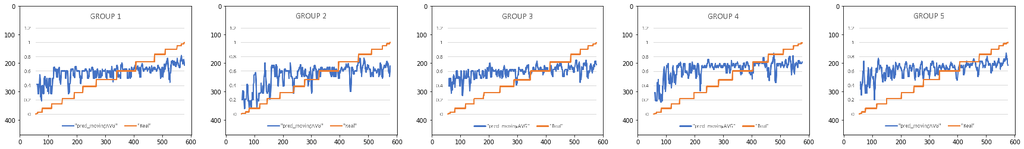

```python
import matplotlib.pyplot as plt
import matplotlib.image as mpimg
plt.clf()
print("LinearSVC Chart Result")
img1=mpimg.imread('SVC_Group1.png')
img2=mpimg.imread('SVC_Group2.png')
img3=mpimg.imread('SVC_Group3.png')
img4=mpimg.imread('SVC_Group4.png')
img5=mpimg.imread('SVC_Group5.png')
fig, (ax1, ax2, ax3, ax4, ax5) = plt.subplots(1,5,figsize=(30,10))
p1 = ax1.imshow(img1)
p2 = ax2.imshow(img2)
p3 = ax3.imshow(img3)
p4 = ax4.imshow(img4)
p5 = ax5.imshow(img5)
plt.show()
```

```
LogisticRegression Chart Result
```

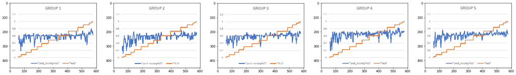

```python
print("LogisticRegression Chart Result")
img1=mpimg.imread('LR_Group1.png')
img2=mpimg.imread('LR_Group2.png')
img3=mpimg.imread('LR_Group3.png')
img4=mpimg.imread('LR_Group4.png')
img5=mpimg.imread('LR_Group5.png')
fig, (ax1, ax2, ax3, ax4, ax5) = plt.subplots(1,5,figsize=(30,10))
p1 = ax1.imshow(img1)
p2 = ax2.imshow(img2)
p3 = ax3.imshow(img3)
p4 = ax4.imshow(img4)
p5 = ax5.imshow(img5)
plt.show()
```

```
MLPClassifier Chart Result
```

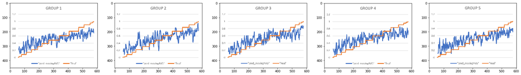

```python
plt.close()
print("MLPClassifier Chart Result")
img1=mpimg.imread('MLP_Group1.png')
img2=mpimg.imread('MLP_Group2.png')
img3=mpimg.imread('MLP_Group3.png')
img4=mpimg.imread('MLP_Group4.png')
img5=mpimg.imread('MLP_Group5.png')
fig, (ax1, ax2, ax3, ax4, ax5) = plt.subplots(1,5,figsize=(30,10))
p1 = ax1.imshow(img1)
p2 = ax2.imshow(img2)
p3 = ax3.imshow(img3)
p4 = ax4.imshow(img4)
p5 = ax5.imshow(img5)
plt.show()
```

```
RandomForestClassifier Chart Result
```

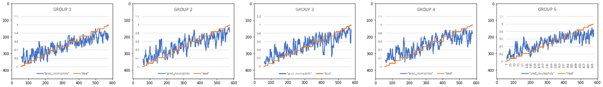

```python
plt.close()
print("RandomForestClassifier Chart Result")
img1=mpimg.imread('RF_Group1.png')
img2=mpimg.imread('RF_Group2.png')
img3=mpimg.imread('RF_Group3.png')
img4=mpimg.imread('RF_Group4.png')
img5=mpimg.imread('RF_Group5.png')
fig, (ax1, ax2, ax3, ax4, ax5) = plt.subplots(1,5,figsize=(30,10))
p1 = ax1.imshow(img1)
p2 = ax2.imshow(img2)
p3 = ax3.imshow(img3)
p4 = ax4.imshow(img4)
p5 = ax5.imshow(img5)
plt.show()
```

Analysis on the new methods

With these four groups of pictures, we can clearly get the relation between predictions and real values for each model. Firstly, for SVM and Logistic Regression, although the blue lines in most of the pictures has a positively increasing tendency at the left part of the picture, we still cannot say they are efficient methods, because no matter which group we focus on, the blue line is just like fluctuating between the middle value, and it is impossible to get the increasing tendency from any pictures for SVM and Logistic Regression. My first thoughts on the reason why these two models failed is some extreme values(not outliers) in the dataset dominate the model, making the models not effective as we expected.(We certainly cannot remove all the skeptical extreme values because extreme values contains some meaning and information in finance industry)

On the contrary, we see the clear increasing tendency of blue lines in all groups with methods of Random Forest and Neutral Network, all though they are both a little bit conservative in predicting the S&P Rating(meaning it is harder for the model to give side values rather than middle values, beacuse in the left part of the pictures, blue line are mostly above the orange line and in the right part of the pictures, blue line are mostly below the orange line). But in all, we can conclude Random Forest and Neutral Network are efficient models for making predictions on the S&P Rating

Model fitting--Market Cap

For Market Cap, it is a regression problem,so the models used in this part include Support Vector Machines, Elastic Net, Random Forest, and Neural network, covering most of the machine learning field and they are all regular and common techniques used in data science area. During the fitting process, we also print out the score of each test for every factor.

```python
#get the corresponding factors
X_forCap=scaled_df_for_Forecast[FinalVarName_ForCap]
```

```python
from sklearn.neural_network import MLPRegressor
from sklearn.svm import LinearSVR
from sklearn.ensemble import RandomForestRegressor
from sklearn.linear_model import ElasticNetCV
model_Name_List=["ElasticNetCV","MLPRegressor","LinearSVR","RandomForestRegressor"]
modelList=[ElasticNetCV(),MLPRegressor(max_iter=800),LinearSVR(),RandomForestRegressor()]

for model,modelName in zip(modelList,model_Name_List):
    i=1
    temp_Result=pd.DataFrame()
    print(modelName)
    for train_index, test_index in kf.split(X_forCap):
        model.fit(X_forCap.iloc[train_index], scaled_Y_MktCap.iloc[train_index])
        print(model.score(X_forCap.iloc[test_index], scaled_Y_MktCap.iloc[test_index]))
        temp_Result["Pred "+str(i)]=model.predict(X_forCap.iloc[test_index])
        temp_Result["Real "+str(i)]=scaled_Y_MktCap.iloc[test_index].values
        #for i,j in zip(scaled_Y_Rating.iloc[test_index],model.predict(X_forRating.iloc[test_index])):
            #print(i,j)
        i=i+1
    temp_Result.to_csv("Cap_TestResult_"+modelName+".csv")
```

```
ElasticNetCV
0.8215678248565894
0.5521575460285828
0.6589299020267294
0.6111476388548334
0.7365412112764025
MLPRegressor
0.9134749185846127
0.4535404322828898
0.6086213445237679
0.6484561827958644
0.7476477311321954
LinearSVR
0.729144876529691
0.5551711680836207
0.6646871683591395
0.6219607691596941
0.6485793953962471
RandomForestRegressor
0.5155095795408497
0.4879540524777518
0.7962121806719864
0.7117678369400332
0.7445810947119327
```

Analysis

The results are not bad, the average score for Elastic Net, Neutral Network, SVM and Random Forest are approximately 0.67, 0.67, 0.64 and 0.65 respectively. However, unlike a classification problem, it is hard to interpret these scores. What does score of 0.67 mean? Is it good or bad? Without the meaning of these scores, we hardly can draw out our conclusions.

Therefore, I generate a new method to evaluate these models. With the predicted data and real data, I create a index representing the prediction bias: abs(abs(prediction)-abs(real value))/abs(real value). For each model, we count the percentage of samples with prediction bias less than 10%, 20%, 30% and 40% respectively. You could say, the prediction with 40% bias is not a precise prediction. However, the prediction with 40% bias is still in the same order of magnitude with the real value, resulting in the comapny with predicted value probably can be divided into the same group of similar company size with the company with real value, which indicated 40% bias is still a meaningful threshold for evaluating these models.

```
Result for predicting MktCap
```

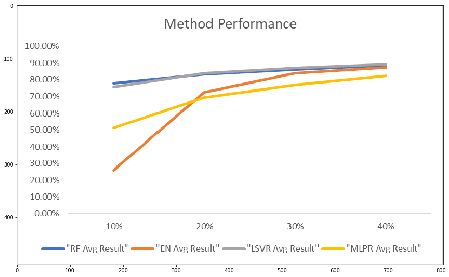

```python
plt.close()
print("Result for predicting MktCap")
img=mpimg.imread('Cap_SumResult.png')
plt.figure(figsize = (15,15))
imgplot = plt.imshow(img)
plt.show()
```

Analysis on the new method

Clearly, Random Forest and SVM perform the best. In any level of thresholds, the estimation accuracy is above 70%. We can consider Random Forest and SVM as the effcient models to estimate the market cap of companies. Moreover, as we mentioned before, if we consider the 40% bias threshold, all methods reach at least 70% accuracy,meaning that, if we are aiming to classify new companies based on the predicted market cap, all these four methods can be seen as the useful tools to make this prediction.

The end